# Variable Transformations

Ryan Miller

## The Need for Transformation

- The variables recorded in a dataset aren’t always conducive to an informative visualization or a statistically valid analysis
  - This presentation will cover 3 strategies for transforming variables to yield more useful and/or more interpretable results
  - These strategies are: **log-transformations**, **standardization** (centering and rescaling), and **discretization**

## Log Transformations

- Right-skewed variables are common, and they can be problematic for both visualizations and statistical methods that use normality assumptions
- Shown below are data on 53,940 diamonds sold by an online retailer
  - Question: How can you tell that both of the variables depicted are right-skewed?

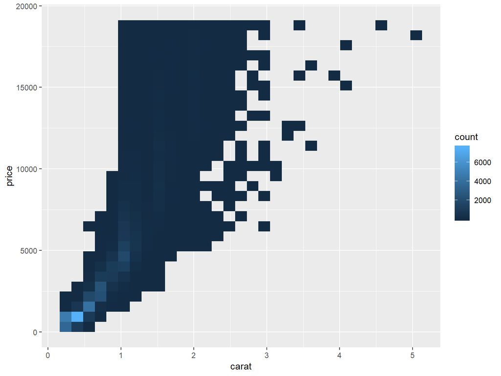

## Log Transformations

- Taking the *logarithm* of a variable can alleviate right-skew (and reduce the impact of outliers) while retaining interpretability
  - A 1-unit increase in the $log_2(carat)$ is a doubling in carat, a nifty interpretation
  - On the $log_2$ scale, we see a clear linear relationship between “Carat” and “Price”

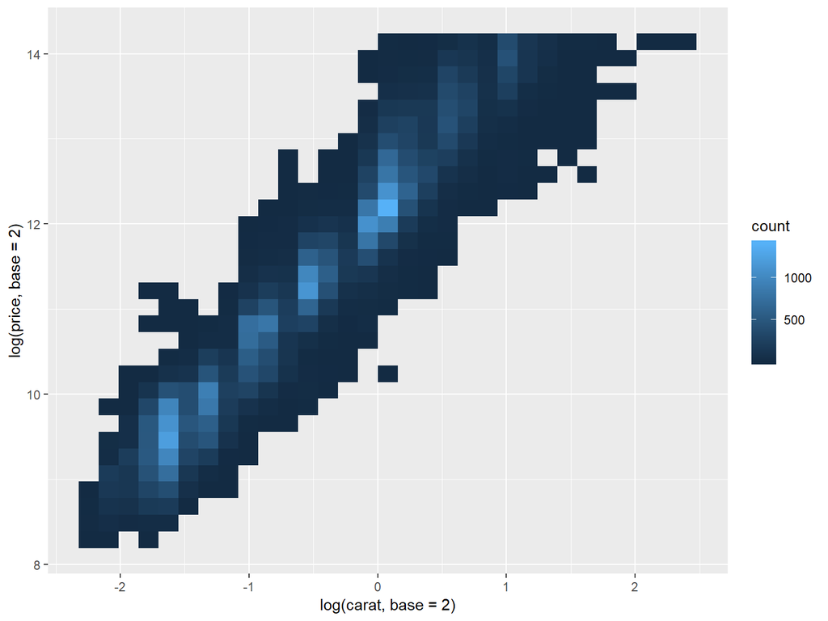

## Log Transformations

- Recall that **linear regression** operates under the assumption the residuals are approximately normally distributed
  - If we model “Price” using “Caret” this assumption is violated
  - But, the assumption is reasonable if we transform each variable using a base-2 logarithm

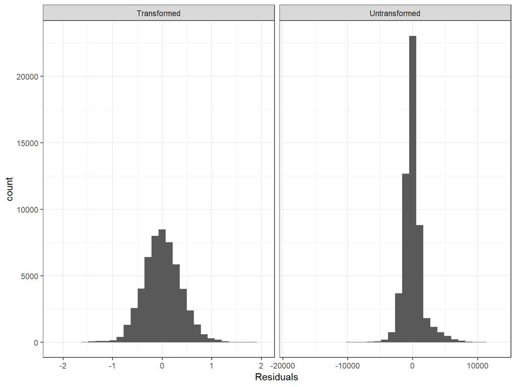

## Interpreting Log-Transformed Variables

- The log-transformation is simple and interpretable, recall:
  - A 1 unit increase in the variable `log2_carat` is a doubling in carat
  - A 1 unit increase in the variable `log2_price` is a doubling in price
- Question: How would you interpret the effect of “Lot Area” in each of the plots shown below?

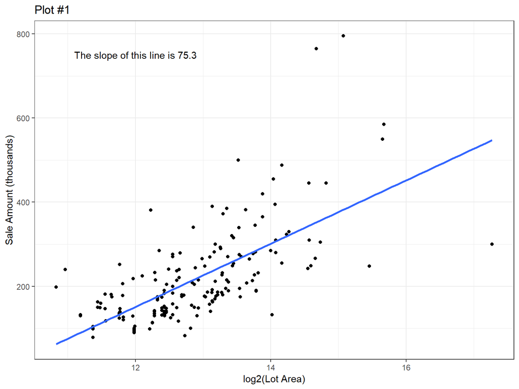

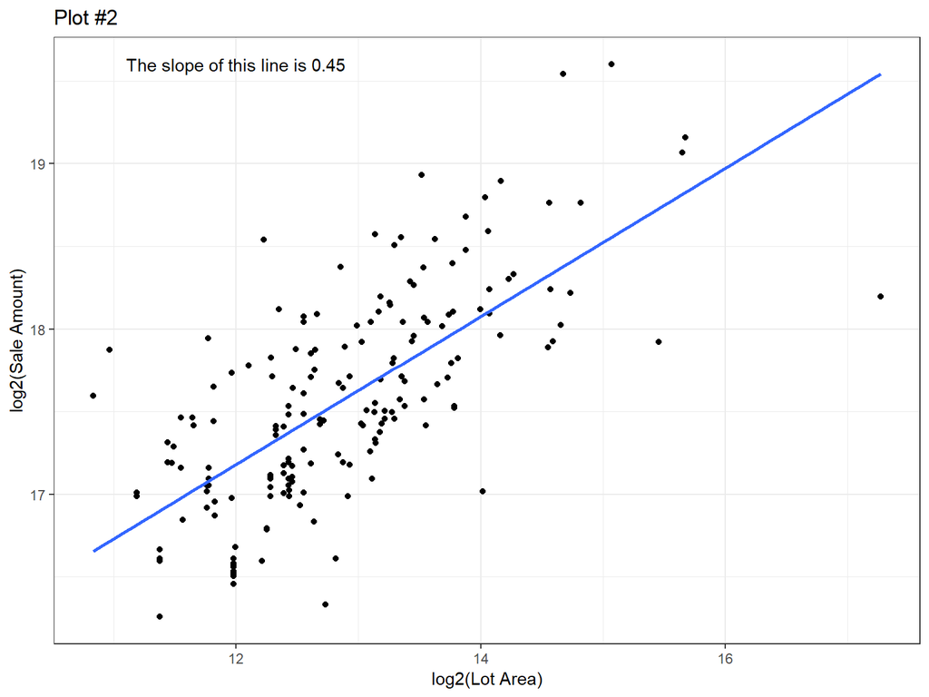

## Interpreting Log-Transformed Variables - Solution

- In Plot #1, a doubling of lot area (a 1-unit increase on the log2-scale) is expected to increase a home’s price by $ 75.3k
- In Plot #2, a doubling of lot area (a 1-unit increase on the log2-scale) is expected to increase a home’s price by a factor of $2^0.45$, or a 36.6% increase in price

## Standardization

- Suppose we want to know whether lot area of the number of bedrooms has larger impact on a home’s sale price
- We could use simple linear regression slopes to summarize the impact of each variable on sale price (in thousands)
  - The coefficient of lot area (acres) is 239.5
  - The coefficient of bedrooms is 45.6
- Question: Which variable has a greater impact?

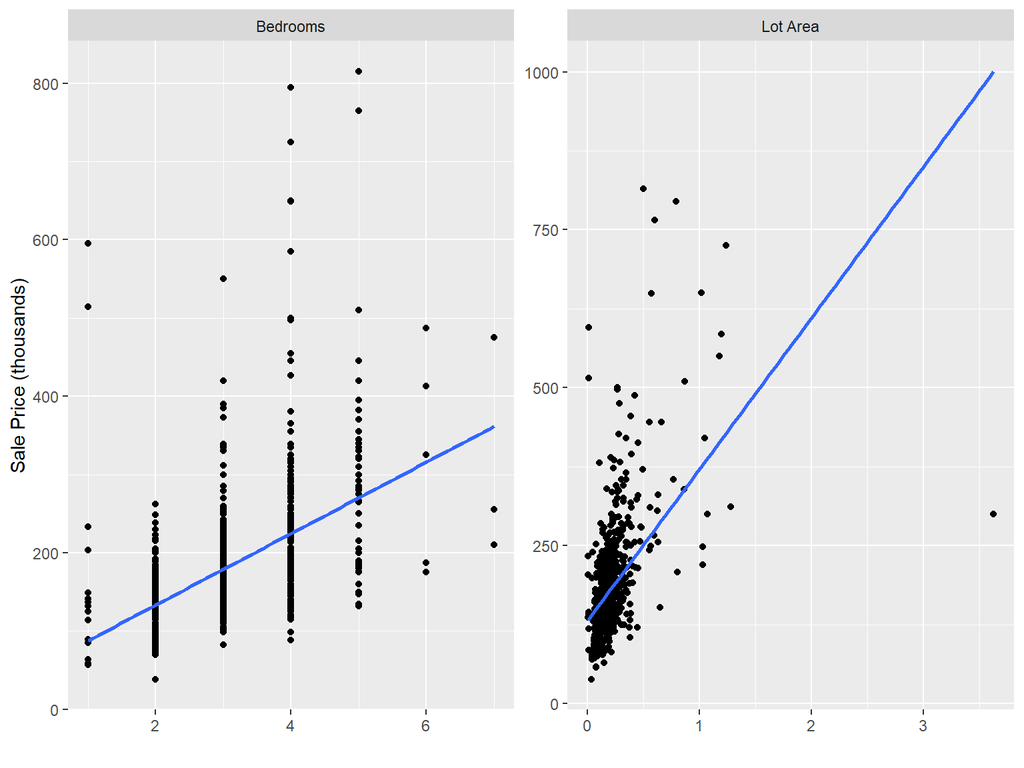

## Standardization

- A 1 acre increase in lot area isn’t comparable with a 1 bedroom increase, so these slopes don’t tell us which variable has a larger impact
- A better approach would compare the effect of a *1 standard deviation increase* in each variable
  - In R, the `scale` function will center and standardize a variable, thereby transforming its original values to [z-scores](https://en.wikipedia.org/wiki/Standard_score)
  - We can refit our models using the standardized versions of “bedrooms” and “lot area”. Now we see that lot area has a slightly larger impact with a 1 standard deviation increase leading to an expected increase in sale price of $46,590

```r
y <- data$sale.amount/1000
x1 <- scale(data$area.lot)
x2 <- scale(data$bedrooms)

lm(y ~ x1)
```

```
##
## Call:
## lm(formula = y ~ x1)
##
## Coefficients:
## (Intercept)           x1
##      180.10        46.59
```

```r
lm(y ~ x2)
```

```
##
## Call:
## lm(formula = y ~ x2)
##
## Coefficients:
## (Intercept)           x2
##      180.10        45.21
```

## Discretization

- The final type of transformation we’ll discuss today is **discretization**, or consolidating a numeric variable into discrete ordinal categories
- To motivate discretization, we’ll look at the survival of passengers on the Titanic by age
  - Question: How does age relate to survival? Who’s more likely to survive, a 5 year-old or a 25 year-old? How about a 25 year-old, a 45 year-old, or 65 year-old?

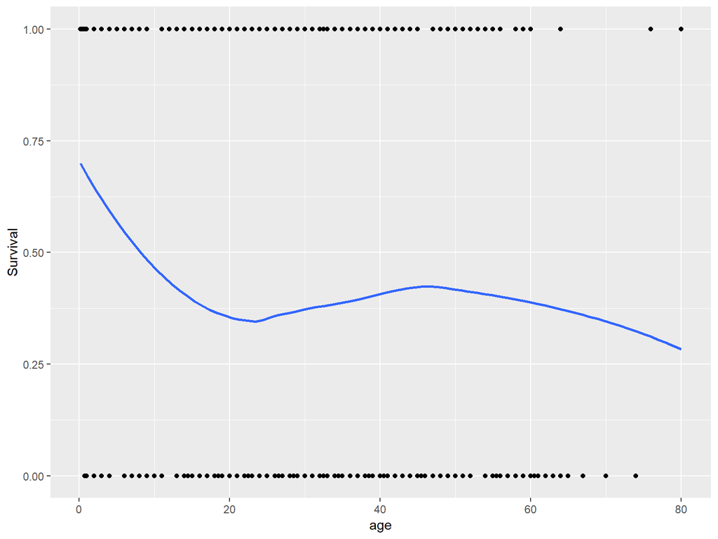

## Discretization

- The impact of age is drastic at young ages, we see that children under age 10 were much more likely to survive than adults
- However, among adults there doesn’t appear to be much difference in survival
  - We might consider splitting age into young children (ages 12 and under) and older children plus adults (ages 13 and older) using the `cut` function
  - This simplifies the data, while retaining the important information from the original variable

```r
data$age_discrete = cut(data$age, breaks = c(0,12,99))
```

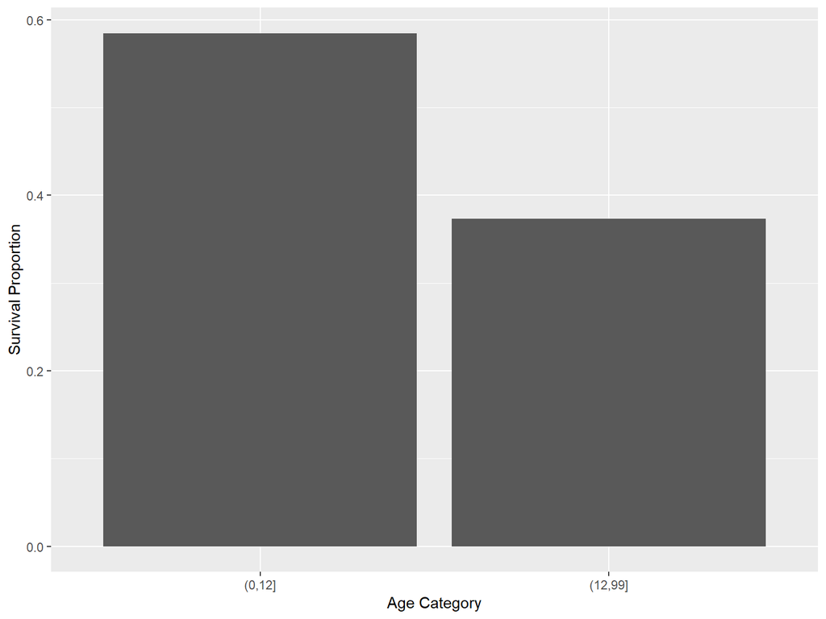

## When to Consider Discretization

- Discretization makes sense when your original data doesn’t have a linear relationship, and instead contains meaningful groups (ie: infants, children, adults) with similar outcomes
- Discretization can lead to a substantial loss of information when you do have a smooth relationship between explanatory and response variable
- Discretization can also be useful in trying to express complex multivariate relationships in a single visualization, as plots can be *faceted* (stratified) or colored using categorical values

## Example of Multivariate Relationship

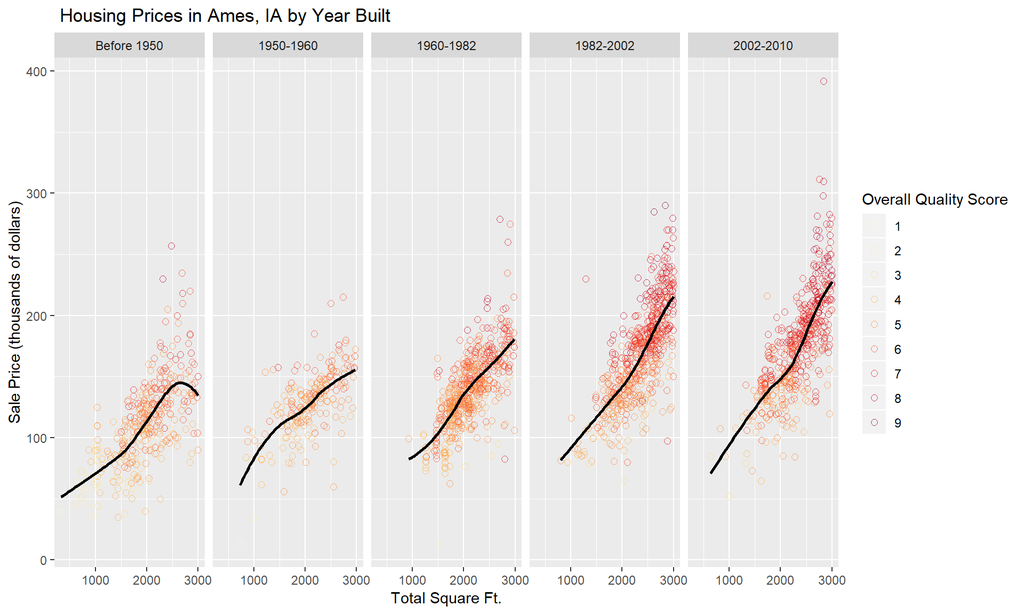

## Takeaways

- Consider a log-transformation when skew or outliers make it difficult to effectively utilize a variable
- Consider standardization when seeking to understand or compare variables with different scales (units)
- Consider discretization when it can simplify a numeric variable for analysis or visualization without a loss of information
- Always keep the Simple-to-Complex principle in mind, avoid transformations that complicate your analysis without a clear benefit